```python
import pandas as pd
import numpy as np
# load the datasets
State_tax__users = pd.read_excel("phonepe-pulse_raw-data_q12018-to-q22021-v0-1-5-1720351752.xlsx", sheet_name = 0)
State_tax_split = pd.read_excel("phonepe-pulse_raw-data_q12018-to-q22021-v0-1-5-1720351752.xlsx", sheet_name = 1)
State_device_data = pd.read_excel("phonepe-pulse_raw-data_q12018-to-q22021-v0-1-5-1720351752.xlsx", sheet_name = 2)
District_tax_users = pd.read_excel("phonepe-pulse_raw-data_q12018-to-q22021-v0-1-5-1720351752.xlsx", sheet_name = 3)
District_demographics = pd.read_excel("phonepe-pulse_raw-data_q12018-to-q22021-v0-1-5-1720351752.xlsx", sheet_name = 4)
```

# Task 1: Data Loading and Understanding

Question 1.1: Load each dataset and display its structure

```python
State_tax__users.head(5)
```

|  | State | Year | Quarter | Transactions | Amount (INR) | ATV (INR) | Registered Users | App Opens |
| --- | --- | --- | --- | --- | --- | --- | --- | --- |
| 0 | Andaman & Nicobar Islands | 2018 | 1 | 6658 | 1.463176e+07 | 2197.621091 | 6740 | 0 |
| 1 | Andaman & Nicobar Islands | 2018 | 2 | 11340 | 2.833854e+07 | 2498.989022 | 9405 | 0 |
| 2 | Andaman & Nicobar Islands | 2018 | 3 | 16265 | 5.555747e+07 | 3415.768284 | 12149 | 0 |
| 3 | Andaman & Nicobar Islands | 2018 | 4 | 23758 | 9.054834e+07 | 3811.277720 | 15222 | 0 |
| 4 | Andaman & Nicobar Islands | 2019 | 1 | 30486 | 1.022997e+08 | 3355.630147 | 18596 | 0 |

2. Load the State_TxnSplit dataset and display its bottom 10 rows

```python
State_tax_split.tail(10)
```

|  | State | Year | Quarter | Transaction Type | Transactions | Amount (INR) | ATV (INR) |
| --- | --- | --- | --- | --- | --- | --- | --- |
| 2504 | West Bengal | 2021 | 1 | Peer-to-peer payments | 53869075 | 2.022402e+11 | 3754.292226 |
| 2505 | West Bengal | 2021 | 1 | Merchant payments | 37143701 | 2.891834e+10 | 778.553104 |
| 2506 | West Bengal | 2021 | 1 | Recharge & bill payments | 26673733 | 1.133967e+10 | 425.124820 |
| 2507 | West Bengal | 2021 | 1 | Financial Services | 166727 | 1.754458e+08 | 1052.293941 |
| 2508 | West Bengal | 2021 | 1 | Others | 400816 | 2.635025e+08 | 657.415236 |
| 2509 | West Bengal | 2021 | 2 | Peer-to-peer payments | 64661051 | 2.308123e+11 | 3569.572026 |
| 2510 | West Bengal | 2021 | 2 | Merchant payments | 41696787 | 3.478787e+10 | 834.305703 |
| 2511 | West Bengal | 2021 | 2 | Recharge & bill payments | 34799709 | 1.333145e+10 | 383.090958 |
| 2512 | West Bengal | 2021 | 2 | Financial Services | 190537 | 1.864665e+08 | 978.636630 |
| 2513 | West Bengal | 2021 | 2 | Others | 549353 | 3.167447e+08 | 576.577748 |

```python
3.	## Load the State_DeviceData dataset and display 10 rows from the middle of the dataset.
```

```
3.0
```

```python
total_rows = len(State_device_data)
start_index = total_rows // 2 - 5
middle_rows = State_device_data.iloc[start_index:start_index+10]
print(middle_rows)
```

```
            State  Year  Quarter     Brand  Registered Users  Percentage
2767       Ladakh  2021        2   OnePlus              1741    0.023198
2768       Ladakh  2021        2  Motorola               922    0.012285
2769       Ladakh  2021        2    Huawei               894    0.011912
2770       Ladakh  2021        2    Lenovo               490    0.006529
2771       Ladakh  2021        2    Others              2610    0.034778
2772  Lakshadweep  2018        1   Samsung               102    0.203593
2773  Lakshadweep  2018        1    Xiaomi               100    0.199601
2774  Lakshadweep  2018        1      Vivo                67    0.133733
2775  Lakshadweep  2018        1      Oppo                56    0.111776
2776  Lakshadweep  2018        1    Huawei                25    0.049900
```

# 4. Load the District_Txn and Users dataset and display its first 10 rows and last 10 rows.

```python
first_10_rows = District_tax_users.head(10)
last_10_rows = District_tax_users.tail(10)
print(first_10_rows)
print(last_10_rows)
```

```
                       State  Year  Quarter                  District  Code  \
0  Andaman & Nicobar Islands  2018        1                  Nicobars  AN01
1  Andaman & Nicobar Islands  2018        1  North And Middle Andaman  AN02
2  Andaman & Nicobar Islands  2018        1             South Andaman  AN03
3  Andaman & Nicobar Islands  2018        2                  Nicobars  AN01
4  Andaman & Nicobar Islands  2018        2  North And Middle Andaman  AN02
5  Andaman & Nicobar Islands  2018        2             South Andaman  AN03
6  Andaman & Nicobar Islands  2018        3                  Nicobars  AN01
7  Andaman & Nicobar Islands  2018        3  North And Middle Andaman  AN02
8  Andaman & Nicobar Islands  2018        3             South Andaman  AN03
9  Andaman & Nicobar Islands  2018        4                  Nicobars  AN01

   Transactions  Amount (INR)    ATV (INR)  Registered Users  App Opens
0           528  1.139849e+06  2158.804548               262          0
1           442  9.316631e+05  2107.835016               632          0
```

[output cut: 31 more lines]

5. Load the District Demographics dataset and display every 10th row.

```python
every_10th_rows= District_demographics.iloc[::10]
print (every_10th_rows)
```

```
                 State       District   Headquarters  Population  \
0       Andhra Pradesh      Anantapur      Anantapur     4083315
10      Andhra Pradesh  Visakhapatnam  Visakhapatnam     4288113
20   Arunachal Pradesh      Lepa Rada          Basar           0
30   Arunachal Pradesh          Siang         Pangin       31920
40               Assam        Barpeta        Barpeta     1693622
..                 ...            ...            ...         ...
700         Chandigarh     Chandigarh     Chandigarh     1055450
710    Jammu & Kashmir          Jammu          Jammu     1526406
720    Jammu & Kashmir          Samba          Samba      318611
730              Delhi    North Delhi   Sadar Bazaar      887978
740         Puducherry     Puducherry    Pondicherry      950289

     Area (sq km)  Density  Code Alternate Name
0         19130.0      213  AP01      Anantapur
10        11161.0      384  AP10  Visakhapatnam
20            0.0        0  AR08      Lepa Rada
30         2919.0       11  AR18          Siang
40         3245.0      520  AS03        Barpeta
..            ...      ...   ...            ...
700         114.0     9258  CH01     Chandigarh
710        3097.0      596  JK07          Jammu
720         913.0      318  JK17          Samba
730          59.0    14557  DL04          North
740         293.0     3232  PY03     Puducherry

[75 rows x 8 columns]
```

## Question 1.2: Display basic statistics and data types for each dataset

```python
1.For each dataset, display the summary statistics (mean, median, std, etc.) for numerical columns.
```

```python
State_tax__users.describe()
```

|  | Year | Quarter | Transactions | Amount (INR) | ATV (INR) | Registered Users | App Opens |
| --- | --- | --- | --- | --- | --- | --- | --- |
| count | 504.000000 | 504.000000 | 5.040000e+02 | 5.030000e+02 | 504.000000 | 5.040000e+02 | 5.040000e+02 |
| mean | 2019.285714 | 2.357143 | 4.074000e+07 | 7.083332e+10 | 1993.471543 | 4.777501e+06 | 9.774471e+07 |
| std | 1.031181 | 1.109971 | 8.228714e+07 | 1.440902e+11 | 607.464894 | 6.644496e+06 | 2.042376e+08 |
| min | 2018.000000 | 1.000000 | 7.780000e+02 | 1.928611e+06 | 0.000000 | 5.010000e+02 | 0.000000e+00 |
| 25% | 2018.000000 | 1.000000 | 5.925578e+05 | 1.167157e+09 | 1598.910667 | 1.574202e+05 | 0.000000e+00 |
| 50% | 2019.000000 | 2.000000 | 6.217487e+06 | 1.051605e+10 | 1861.380589 | 1.747914e+06 | 2.930574e+06 |
| 75% | 2020.000000 | 3.000000 | 4.363675e+07 | 6.947045e+10 | 2259.087924 | 7.320945e+06 | 8.615022e+07 |
| max | 2021.000000 | 4.000000 | 5.736165e+08 | 1.027958e+12 | 3938.733850 | 3.966470e+07 | 1.208084e+09 |

```python
State_tax_split.describe()
```

|  | Year | Quarter | Transactions | Amount (INR) | ATV (INR) |
| --- | --- | --- | --- | --- | --- |
| count | 2514.000000 | 2514.000000 | 2.514000e+03 | 2.514000e+03 | 2514.000000 |
| mean | 2019.286794 | 2.358393 | 8.167446e+06 | 1.443978e+10 | 1349.927929 |
| std | 1.030807 | 1.109251 | 2.423645e+07 | 5.995054e+10 | 1534.866221 |
| min | 2018.000000 | 1.000000 | 2.000000e+00 | 3.439721e+01 | 17.198606 |
| 25% | 2018.000000 | 1.000000 | 2.788075e+04 | 1.762412e+07 | 385.735827 |
| 50% | 2019.000000 | 2.000000 | 2.687980e+05 | 1.901189e+08 | 720.940406 |
| 75% | 2020.000000 | 3.000000 | 3.683230e+06 | 2.661248e+09 | 1352.790116 |
| max | 2021.000000 | 4.000000 | 2.795990e+08 | 8.721520e+11 | 7767.539936 |

```python
State_device_data.describe()
```

|  | Year | Quarter | Registered Users | Percentage |
| --- | --- | --- | --- | --- |
| count | 5544.000000 | 5544.000000 | 5.544000e+03 | 5544.000000 |
| mean | 2019.285714 | 2.357143 | 4.343183e+05 | 0.090909 |
| std | 1.030250 | 1.108970 | 9.056069e+05 | 0.083095 |
| min | 2018.000000 | 1.000000 | 1.000000e+01 | 0.006373 |
| 25% | 2018.000000 | 1.000000 | 8.055750e+03 | 0.021588 |
| 50% | 2019.000000 | 2.000000 | 7.442250e+04 | 0.056914 |
| 75% | 2020.000000 | 3.000000 | 3.978875e+05 | 0.143626 |
| max | 2021.000000 | 4.000000 | 9.764252e+06 | 0.478367 |

```python
District_tax_users.describe()
```

|  | Year | Quarter | Transactions | Amount (INR) | ATV (INR) | Registered Users | App Opens |
| --- | --- | --- | --- | --- | --- | --- | --- |
| count | 10248.000000 | 10248.000000 | 1.024800e+04 | 1.024800e+04 | 10244.000000 | 1.024800e+04 | 1.024800e+04 |
| mean | 2019.285714 | 2.357143 | 2.003607e+06 | 3.542311e+09 | 1909.796545 | 2.349591e+05 | 4.807117e+06 |
| std | 1.030208 | 1.108924 | 9.613466e+06 | 1.473154e+10 | 600.943349 | 4.605978e+05 | 1.562541e+07 |
| min | 2018.000000 | 1.000000 | 0.000000e+00 | 0.000000e+00 | 84.944283 | 2.200000e+01 | 0.000000e+00 |
| 25% | 2018.000000 | 1.000000 | 1.031418e+05 | 1.756668e+08 | 1554.589051 | 3.619550e+04 | 0.000000e+00 |
| 50% | 2019.000000 | 2.000000 | 3.763065e+05 | 6.784562e+08 | 1863.135530 | 1.067640e+05 | 6.403025e+05 |
| 75% | 2020.000000 | 3.000000 | 1.272815e+06 | 2.377256e+09 | 2203.083552 | 2.573165e+05 | 4.346320e+06 |
| max | 2021.000000 | 4.000000 | 3.487128e+08 | 4.444224e+11 | 11209.980550 | 1.060461e+07 | 5.544197e+08 |

```python
District_demographics.describe()
```

|  | Population | Area (sq km) | Density |
| --- | --- | --- | --- |
| count | 7.420000e+02 | 742.000000 | 742.000000 |
| mean | 1.668555e+06 | 4395.373120 | 838.512129 |
| std | 1.458849e+06 | 4254.676124 | 2754.406896 |
| min | 0.000000e+00 | 0.000000 | 0.000000 |
| 25% | 6.530815e+05 | 2039.750000 | 198.000000 |
| 50% | 1.322359e+06 | 3402.500000 | 353.000000 |
| 75% | 2.297440e+06 | 5432.750000 | 686.250000 |
| max | 1.008285e+07 | 45652.000000 | 36155.000000 |

2. Display the data types of each column in each dataset.

```python
State_Txn_and_Users = pd.read_excel("phonepe-pulse_raw-data_q12018-to-q22021-v0-1-5-1720351752.xlsx", sheet_name = 0)
print(State_Txn_and_Users.dtypes)
```

```
State                object
Year                  int64
Quarter               int64
Transactions          int64
Amount (INR)        float64
ATV (INR)           float64
Registered Users      int64
App Opens             int64
dtype: object
```

```python
State_tax_split = pd.read_excel("phonepe-pulse_raw-data_q12018-to-q22021-v0-1-5-1720351752.xlsx", sheet_name = 1)
print(State_tax_split.dtypes)
```

```
State                object
Year                  int64
Quarter               int64
Transaction Type     object
Transactions          int64
Amount (INR)        float64
ATV (INR)           float64
dtype: object
```

```python
State_device_data = pd.read_excel("phonepe-pulse_raw-data_q12018-to-q22021-v0-1-5-1720351752.xlsx", sheet_name = 2)
print(State_device_data.dtypes)
```

```
State                object
Year                  int64
Quarter               int64
Brand                object
Registered Users      int64
Percentage          float64
dtype: object
```

```python
District_tax_users = pd.read_excel("phonepe-pulse_raw-data_q12018-to-q22021-v0-1-5-1720351752.xlsx", sheet_name = 3)
print(District_tax_users.dtypes)
```

```
State                object
Year                  int64
Quarter               int64
District             object
Code                 object
Transactions          int64
Amount (INR)        float64
ATV (INR)           float64
Registered Users      int64
App Opens             int64
dtype: object
```

```python
District_demographics = pd.read_excel("phonepe-pulse_raw-data_q12018-to-q22021-v0-1-5-1720351752.xlsx", sheet_name = 4)
print(District_demographics.dtypes)
```

[output not shown]

## Question 1.3: Check for missing values

```python
 1.	Identify any missing values in each dataset.
```

```python
State_tax__users.isnull().sum()
```

```
State               0
Year                0
Quarter             0
Transactions        0
Amount (INR)        1
ATV (INR)           0
Registered Users    0
App Opens           0
dtype: int64
```

```python
State_tax_split.isnull().sum()
```

```
State               0
Year                0
Quarter             0
Transaction Type    0
Transactions        0
Amount (INR)        0
ATV (INR)           0
dtype: int64
```

```python
State_device_data.isnull().sum()
```

```
State               0
Year                0
Quarter             0
Brand               0
Registered Users    0
Percentage          0
dtype: int64
```

```python
District_tax_users.isnull().sum()
```

```
State                0
Year                 0
Quarter              0
District             0
Code                28
Transactions         0
Amount (INR)         0
ATV (INR)            4
Registered Users     0
App Opens            0
dtype: int64
```

```python
District_demographics.isnull().sum()
```

```
State             0
District          0
Headquarters      0
Population        0
Area (sq km)      0
Density           0
Code              0
Alternate Name    0
dtype: int64
```

2. Calculate the percentage of missing values for each column that has missing values.

```python
missing_values_percentage = (State_tax__users.isnull().sum() / len(State_tax__users)) * 100

print(missing_values_percentage)
```

```
State               0.000000
Year                0.000000
Quarter             0.000000
Transactions        0.000000
Amount (INR)        0.198413
ATV (INR)           0.000000
Registered Users    0.000000
App Opens           0.000000
dtype: float64
```

```python
missing_values_percentage = (State_tax_split.isnull().sum() / len(State_tax__users)) * 100

print(missing_values_percentage)
```

```
State               0.0
Year                0.0
Quarter             0.0
Transaction Type    0.0
Transactions        0.0
Amount (INR)        0.0
ATV (INR)           0.0
dtype: float64
```

```python
missing_values_percentage = (State_device_data.isnull().sum() / len(State_device_data)) * 100

print(missing_values_percentage)
```

```
State               0.0
Year                0.0
Quarter             0.0
Brand               0.0
Registered Users    0.0
Percentage          0.0
dtype: float64
```

```python
missing_values_percentage = (State_device_data.isnull().sum() / len(State_device_data)) * 100

print(missing_values_percentage)
```

```
State               0.0
Year                0.0
Quarter             0.0
Brand               0.0
Registered Users    0.0
Percentage          0.0
dtype: float64
```

```python
missing_values_percentage = (District_demographics.isnull().sum() / len(District_demographics)) * 100

print(missing_values_percentage)
```

```
State             0.0
District          0.0
Headquarters      0.0
Population        0.0
Area (sq km)      0.0
Density           0.0
Code              0.0
Alternate Name    0.0
dtype: float64
```

```python
max_missing_value = State_tax__users.idxmax()
print( max_missing_value)
```

```
State               490
Year                 12
Quarter               3
Transactions        293
Amount (INR)        447
ATV (INR)           189
Registered Users    293
App Opens           293
dtype: int64
```

1.4 Create a Summary

1. Calculate the total number of states and the total number of districts.

```python
total_states = District_demographics['State'].nunique()
print("Total number of states:", total_states)
```

```
Total number of states: 36
```

```python
total_districts = District_demographics['District'].nunique()
print("Total number of districts:", total_districts)
```

```
Total number of districts: 736
```

```python
2.	Identify the state with the highest number of districts. [hint: you can use value_counts() and idxmax()]
```

```python
state_district_counts = District_demographics['State'].value_counts()
state_with_most_districts = state_district_counts.idxmax()
max_districts_count = state_district_counts.max()
print(f"State with the highest number of districts: {state_with_most_districts} ({max_districts_count} districts)")
```

```
State with the highest number of districts: Uttar Pradesh (75 districts)
```

## Task 2: Exploratory Data Analysis (EDA)

Question 2.1: Analyze transaction trends over the years for each state

```python
1.	Calculate the total number of transactions and total transaction amount for each state over the years. Display the results in a tabular format.
```

```python
grouped_data =  State_tax__users .groupby(['State', 'Year']).agg({'Transactions': 'sum', 'Amount (INR)': 'sum'})

# Display the results in a tabular format
print(grouped_data)
```

```
                                Transactions  Amount (INR)
State                     Year
Andaman & Nicobar Islands 2018         58021  1.890761e+08
                          2019        133104  4.734648e+08
                          2020        446274  1.296423e+09
                          2021        586166  1.682854e+09
Andhra Pradesh            2018      77779112  1.220720e+11
...                                      ...           ...
Uttarakhand               2021      44608834  7.727901e+10
West Bengal               2018     120011635  1.115887e+11
                          2019     257900590  2.660145e+11
                          2020     304222327  5.527316e+11
                          2021     260151489  5.223720e+11

[144 rows x 2 columns]
```

2. Identify the top 5 states with the highest transaction volumes and the top 5 states with the lowest transaction volumes. Display the results.

```python
# Identify the top 5 states with the highest transaction
top_5_states = State_tax__users.groupby('State').aggregate({'Transactions': 'sum'}).nlargest(5, columns='Transactions')

# Identify the top 5 states with the lowest transaction
bottom_5_states = State_tax__users.groupby('State').aggregate({'Transactions': 'sum'}).nsmallest(5, columns='Transactions')

# Display the results
print("Top 5 States by Transaction")
print(top_5_states)

print("\nBottom 5 States by Transaction")
print(bottom_5_states)
```

```
Top 5 States by Transaction
                Transactions
State
Karnataka         2981044533
Maharashtra       2833670154
Telangana         2347430243
Andhra Pradesh    1781091169
Rajasthan         1382918930

Bottom 5 States by Transaction
                           Transactions
State
Lakshadweep                       71610
Andaman & Nicobar Islands       1223565
Ladakh                          1880109
Mizoram                         2162776
Meghalaya                       5648913
```

## Question 2.2: Identify the most common transaction types in each state and quarter

1. For each state and quarter, determine the most frequent transaction type. Display the results in a tabular format.

```python
# Group the data by State, Quarter, and Transaction Type, and count the occurrences of each transaction type
grouped_data = State_tax_split.groupby(['State', 'Quarter', 'Transaction Type']).size().reset_index(name='Count')

# Find the most frequent transaction type for each state and quarter
most_frequent_transactions = grouped_data.loc[grouped_data.groupby(['State', 'Quarter'])['Count'].idxmax()]

# Display the results in a tabular format
print(most_frequent_transactions)
```

```
                         State  Quarter    Transaction Type  Count
0    Andaman & Nicobar Islands        1  Financial Services      4
5    Andaman & Nicobar Islands        2  Financial Services      4
10   Andaman & Nicobar Islands        3  Financial Services      3
15   Andaman & Nicobar Islands        4  Financial Services      3
20              Andhra Pradesh        1  Financial Services      4
..                         ...      ...                 ...    ...
695                Uttarakhand        4  Financial Services      3
700                West Bengal        1  Financial Services      4
705                West Bengal        2  Financial Services      4
710                West Bengal        3  Financial Services      3
715                West Bengal        4  Financial Services      3

[144 rows x 4 columns]
```

```python
State_tax__users
```

|  | State | Year | Quarter | Transactions | Amount (INR) | ATV (INR) | Registered Users | App Opens |
| --- | --- | --- | --- | --- | --- | --- | --- | --- |
| 0 | Andaman & Nicobar Islands | 2018 | 1 | 6658 | 1.463176e+07 | 2197.621091 | 6740 | 0 |
| 1 | Andaman & Nicobar Islands | 2018 | 2 | 11340 | 2.833854e+07 | 2498.989022 | 9405 | 0 |
| 2 | Andaman & Nicobar Islands | 2018 | 3 | 16265 | 5.555747e+07 | 3415.768284 | 12149 | 0 |
| 3 | Andaman & Nicobar Islands | 2018 | 4 | 23758 | 9.054834e+07 | 3811.277720 | 15222 | 0 |
| 4 | Andaman & Nicobar Islands | 2019 | 1 | 30486 | 1.022997e+08 | 3355.630147 | 18596 | 0 |
| ... | ... | ... | ... | ... | ... | ... | ... | ... |
| 499 | West Bengal | 2020 | 2 | 57676797 | 1.000994e+11 | 1735.523418 | 13222022 | 198589332 |
| 500 | West Bengal | 2020 | 3 | 79954504 | 1.568134e+11 | 1961.282329 | 14448366 | 246554831 |
| 501 | West Bengal | 2020 | 4 | 100340645 | 1.991655e+11 | 1984.893473 | 15662093 | 291721919 |
| 502 | West Bengal | 2021 | 1 | 118254052 | 2.429372e+11 | 2054.366877 | 16808799 | 316832674 |
| 503 | West Bengal | 2021 | 2 | 141897437 | 2.794348e+11 | 1969.273138 | 17979979 | 275341466 |

504 rows × 8 columns

## Question 2.3: Determine the device brand with the highest number of registered users in each state

1. Identify the device brand with the highest number of registered users in each state. Display the results in a tabular format.

```python
State_device_data
```

|  | State | Year | Quarter | Brand | Registered Users | Percentage |
| --- | --- | --- | --- | --- | --- | --- |
| 0 | Andaman & Nicobar Islands | 2018 | 1 | Xiaomi | 1665 | 0.247033 |
| 1 | Andaman & Nicobar Islands | 2018 | 1 | Samsung | 1445 | 0.214392 |
| 2 | Andaman & Nicobar Islands | 2018 | 1 | Vivo | 982 | 0.145697 |
| 3 | Andaman & Nicobar Islands | 2018 | 1 | Oppo | 501 | 0.074332 |
| 4 | Andaman & Nicobar Islands | 2018 | 1 | OnePlus | 332 | 0.049258 |
| ... | ... | ... | ... | ... | ... | ... |
| 5539 | West Bengal | 2021 | 2 | Lenovo | 350841 | 0.019513 |
| 5540 | West Bengal | 2021 | 2 | Asus | 297579 | 0.016551 |
| 5541 | West Bengal | 2021 | 2 | Huawei | 272965 | 0.015182 |
| 5542 | West Bengal | 2021 | 2 | Apple | 201393 | 0.011201 |
| 5543 | West Bengal | 2021 | 2 | Others | 1928653 | 0.107267 |

5544 rows × 6 columns

```python
# Group the data by 'State' and 'Brand', and count the number of users
grouped_data = State_device_data.groupby(['State', 'Brand'])['Registered Users'].sum().reset_index(name='Registered Users')

# Find the most common device brand in each state
most_common_brands = grouped_data.loc[grouped_data.groupby('State')['Registered Users'].idxmax()]

# Display the results in a tabular format
print(most_common_brands)
```

```
                                    State    Brand  Registered Users
11              Andaman & Nicobar Islands   Xiaomi             97889
22                         Andhra Pradesh   Xiaomi          40061549
34                      Arunachal Pradesh   Xiaomi            437803
46                                  Assam   Xiaomi           6979357
60                                  Bihar   Xiaomi          33721314
73                             Chandigarh   Xiaomi            896628
85                           Chhattisgarh   Xiaomi           8763373
98   Dadra & Nagar Haveli and Daman & Diu   Xiaomi            638834
109                                 Delhi   Xiaomi          24114984
120                                   Goa   Xiaomi           1208672
131                               Gujarat   Xiaomi          28942157
143                               Haryana   Xiaomi          21102142
156                      Himachal Pradesh   Xiaomi           3978888
168                       Jammu & Kashmir   Xiaomi           3471820
```

[output cut: 22 more lines]

## Question 2.4: Create a list of the top district per state based on population

1. For each state, identify the district with the highest population. Display the results in a tabular format.

```python
District_demographics
```

|  | State | District | Headquarters | Population | Area (sq km) | Density | Code | Alternate Name |
| --- | --- | --- | --- | --- | --- | --- | --- | --- |
| 0 | Andhra Pradesh | Anantapur | Anantapur | 4083315 | 19130.0 | 213 | AP01 | Anantapur |
| 1 | Andhra Pradesh | Chittoor | Chittoor | 4170468 | 15152.0 | 275 | AP02 | Chittoor |
| 2 | Andhra Pradesh | East Godavari | Kakinada | 5151549 | 10807.0 | 477 | AP03 | East Godavari |
| 3 | Andhra Pradesh | Guntur | Guntur | 4889230 | 11391.0 | 429 | AP04 | Guntur |
| 4 | Andhra Pradesh | YSR | Kadapa | 2884524 | 15359.0 | 188 | AP13 | YSR |
| ... | ... | ... | ... | ... | ... | ... | ... | ... |
| 737 | Delhi | West Delhi | Rajouri Garden | 2543243 | 112.0 | 19563 | DL11 | West |
| 738 | Puducherry | Karaikal | Karaikal | 200222 | 157.0 | 1275 | PY01 | Karaikal |
| 739 | Puducherry | Mahé | Mahé | 41816 | 9.0 | 4646 | PY02 | Mahe |
| 740 | Puducherry | Puducherry | Pondicherry | 950289 | 293.0 | 3232 | PY03 | Puducherry |
| 741 | Puducherry | Yanam | Yanam | 55626 | 30.0 | 1854 | PY04 | Yanam |

742 rows × 8 columns

```python
# Group the data by 'State' and find the district with the highest population in each state
top_districts = District_demographics.loc[District_demographics.groupby('State')['Population'].idxmax()].reset_index()

# Display the results in a tabular format
print(top_districts[[ 'District', 'Population']])
```

```
                  District  Population
0            South Andaman      238142
1            East Godavari     5151549
2               Papum Pare      176385
3                   Nagaon     2826006
4                    Patna     5772804
5               Chandigarh     1055450
6                   Raipur     2160876
7   Dadra and Nagar Haveli      343709
8         North West Delhi     3656539
9                North Goa      817761
10               Ahmedabad     7208200
11               Faridabad     1798954
12                  Kangra     1507223
13                   Jammu     1526406
```

[output cut: 22 more lines]

2. Create a column chart depicting the district with the highest population for each state.

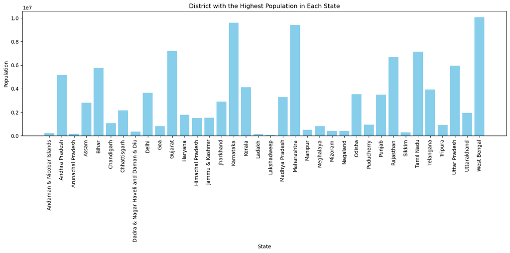

```python
import pandas as pd
import matplotlib.pyplot as plt
plt.figure(figsize=(14, 7))
plt.bar(top_districts['State'], top_districts['Population'], color='skyblue')
plt.title('District with the Highest Population in Each State')
plt.xlabel('State')
plt.ylabel('Population')
plt.xticks(rotation=90)
plt.tight_layout()
plt.show()
```

## Question 2.5: Calculate the average transaction value (ATV) for each state

```python
1.	Compute the average transaction value for each state. Display the results in a tabular format.
```

```python
District_tax_users
```

|  | State | Year | Quarter | District | Code | Transactions | Amount (INR) | ATV (INR) | Registered Users | App Opens |
| --- | --- | --- | --- | --- | --- | --- | --- | --- | --- | --- |
| 0 | Andaman & Nicobar Islands | 2018 | 1 | Nicobars | AN01 | 528 | 1.139849e+06 | 2158.804548 | 262 | 0 |
| 1 | Andaman & Nicobar Islands | 2018 | 1 | North And Middle Andaman | AN02 | 442 | 9.316631e+05 | 2107.835016 | 632 | 0 |
| 2 | Andaman & Nicobar Islands | 2018 | 1 | South Andaman | AN03 | 5688 | 1.256025e+07 | 2208.201361 | 5846 | 0 |
| 3 | Andaman & Nicobar Islands | 2018 | 2 | Nicobars | AN01 | 1120 | 3.072437e+06 | 2743.247239 | 351 | 0 |
| 4 | Andaman & Nicobar Islands | 2018 | 2 | North And Middle Andaman | AN02 | 825 | 1.317863e+06 | 1597.409798 | 911 | 0 |
| ... | ... | ... | ... | ... | ... | ... | ... | ... | ... | ... |
| 10243 | West Bengal | 2021 | 2 | Purba Bardhaman | WB19 | 3920729 | 7.572502e+09 | 1931.401639 | 787970 | 12128849 |
| 10244 | West Bengal | 2021 | 2 | Purba Medinipur | WB20 | 6418522 | 1.515507e+10 | 2361.146027 | 946277 | 15491958 |
| 10245 | West Bengal | 2021 | 2 | Purulia | WB21 | 1895981 | 2.790996e+09 | 1472.059252 | 435131 | 8843358 |
| 10246 | West Bengal | 2021 | 2 | South Twenty Four Parganas | WB22 | 6661813 | 1.339853e+10 | 2011.243709 | 1286588 | 19344293 |
| 10247 | West Bengal | 2021 | 2 | Uttar Dinajpur | WB23 | 2253385 | 5.564221e+09 | 2469.272118 | 392388 | 8184990 |

10248 rows × 10 columns

```python
# Group the data by 'State' and calculate the total transactions and amount
grouped_data = District_tax_users.groupby('State').agg({'Transactions': 'sum', 'Amount (INR)': 'sum'}).reset_index()

# Calculate the average transaction value (ATV) for each state
grouped_data['ATV (INR)'] = grouped_data['Amount (INR)'] / grouped_data['Transactions']

# Display the results in a tabular format
print(grouped_data[['State', 'ATV (INR)']])
```

```
                                   State    ATV (INR)
0              Andaman & Nicobar Islands  2976.399178
1                         Andhra Pradesh  2167.374813
2                      Arunachal Pradesh  2766.333539
3                                  Assam  2277.175192
4                                  Bihar  2297.474906
5                             Chandigarh  2104.990740
6                           Chhattisgarh  1718.150602
7   Dadra & Nagar Haveli and Daman & Diu  1497.232192
8                                  Delhi  1631.940078
9                                    Goa  1808.372977
10                               Gujarat  1803.167412
11                               Haryana  1866.717628
12                      Himachal Pradesh  1846.955544
13                       Jammu & Kashmir  2430.351780
```

[output cut: 22 more lines]

```python
2.	Identify the top 5 states with the highest ATV and the top 5 states with the lowest ATV. Display the results.
```

```python
# Group the data by 'State' and calculate the total transactions and amount
grouped_data = District_tax_users.groupby('State').agg({'Transactions': 'sum', 'Amount (INR)': 'sum'}).reset_index()

# Calculate the average transaction value (ATV) for each state
grouped_data['ATV'] = grouped_data['Amount (INR)'] / grouped_data['Transactions']

# Identify the top 5 states with the highest ATV
top_5_states = grouped_data.nlargest(5, 'ATV')

print("Top 5 States with Highest ATV:")
print(top_5_states[['State', 'ATV']])

# Identify the top 5 states with the lowest ATV
bottom_5_states = grouped_data.nsmallest(5, 'ATV')
print("\nTop 5 States with Lowest ATV:")
print(bottom_5_states[['State', 'ATV']])
```

```
Top 5 States with Highest ATV:
                        State          ATV
17                     Ladakh  3514.146494
0   Andaman & Nicobar Islands  2976.399178
23                    Mizoram  2920.848685
21                    Manipur  2905.757931
24                   Nagaland  2794.140997

Top 5 States with Lowest ATV:
                                   State          ATV
15                             Karnataka  1463.042846
7   Dadra & Nagar Haveli and Daman & Diu  1497.232192
20                           Maharashtra  1514.288897
35                           West Bengal  1541.683482
8                                  Delhi  1631.940078
```

## Question 2.6: Analyze app usage trends

1. Calculate the total number of app opens over the years and quarters for each state. Display the results in a tabular format

```python
State_tax__users
```

|  | State | Year | Quarter | Transactions | Amount (INR) | ATV (INR) | Registered Users | App Opens |
| --- | --- | --- | --- | --- | --- | --- | --- | --- |
| 0 | Andaman & Nicobar Islands | 2018 | 1 | 6658 | 1.463176e+07 | 2197.621091 | 6740 | 0 |
| 1 | Andaman & Nicobar Islands | 2018 | 2 | 11340 | 2.833854e+07 | 2498.989022 | 9405 | 0 |
| 2 | Andaman & Nicobar Islands | 2018 | 3 | 16265 | 5.555747e+07 | 3415.768284 | 12149 | 0 |
| 3 | Andaman & Nicobar Islands | 2018 | 4 | 23758 | 9.054834e+07 | 3811.277720 | 15222 | 0 |
| 4 | Andaman & Nicobar Islands | 2019 | 1 | 30486 | 1.022997e+08 | 3355.630147 | 18596 | 0 |
| ... | ... | ... | ... | ... | ... | ... | ... | ... |
| 499 | West Bengal | 2020 | 2 | 57676797 | 1.000994e+11 | 1735.523418 | 13222022 | 198589332 |
| 500 | West Bengal | 2020 | 3 | 79954504 | 1.568134e+11 | 1961.282329 | 14448366 | 246554831 |
| 501 | West Bengal | 2020 | 4 | 100340645 | 1.991655e+11 | 1984.893473 | 15662093 | 291721919 |
| 502 | West Bengal | 2021 | 1 | 118254052 | 2.429372e+11 | 2054.366877 | 16808799 | 316832674 |
| 503 | West Bengal | 2021 | 2 | 141897437 | 2.794348e+11 | 1969.273138 | 17979979 | 275341466 |

504 rows × 8 columns

```python
# Group the data by State, Year, and Quarter, and calculate the total app opens
grouped_data = State_tax__users.groupby(['State', 'Year', 'Quarter'])['App Opens'].sum().reset_index()

# Display the results in a tabular format
print(grouped_data)
```

```
                         State  Year  Quarter  App Opens
0    Andaman & Nicobar Islands  2018        1          0
1    Andaman & Nicobar Islands  2018        2          0
2    Andaman & Nicobar Islands  2018        3          0
3    Andaman & Nicobar Islands  2018        4          0
4    Andaman & Nicobar Islands  2019        1          0
..                         ...   ...      ...        ...
499                West Bengal  2020        2  198589332
500                West Bengal  2020        3  246554831
501                West Bengal  2020        4  291721919
502                West Bengal  2021        1  316832674
503                West Bengal  2021        2  275341466

[504 rows x 4 columns]
```

```python
2.	Identify trends in app usage by creating a line plot showing the number of app opens over time for a selected state.
```

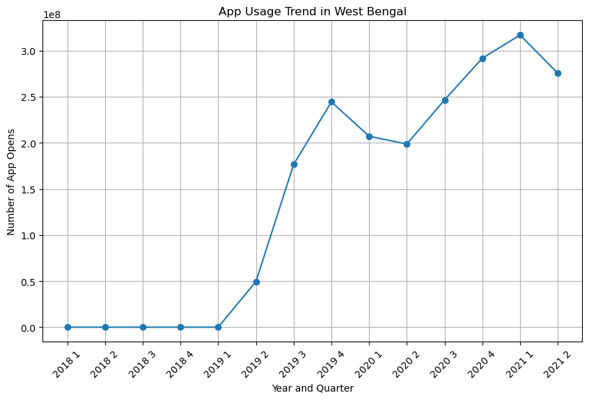

```python
import matplotlib.pyplot as plt
import pandas as pd

# Create DataFrame
grouped_data =  State_tax__users

# Convert 'Year' and 'Quarter' columns to strings
grouped_data['Year'] = grouped_data['Year'].astype(str)
grouped_data['Quarter'] = grouped_data['Quarter'].astype(str)

# Select data for the state 'West Bengal'
state_data = grouped_data[grouped_data['State'] == 'West Bengal']

# Create a line plot
plt.figure(figsize=(10, 6))
plt.plot(state_data['Year'] + ' ' + state_data['Quarter'], state_data['App Opens'], marker='o', linestyle='-')
plt.xlabel('Year and Quarter')
plt.ylabel('Number of App Opens')
plt.title('App Usage Trend in West Bengal')
plt.xticks(rotation=45)
plt.grid(True)
plt.show()
```

## Question 2.7: Distribution of transaction types

1. Create a bar chart showing the distribution of different transaction types for each state for the most recent quarter in the dataset.

```python
 State_tax_split
```

|  | State | Year | Quarter | Transaction Type | Transactions | Amount (INR) | ATV (INR) |
| --- | --- | --- | --- | --- | --- | --- | --- |
| 0 | Andaman & Nicobar Islands | 2018 | 1 | Recharge & bill payments | 4200 | 1.845307e+06 | 439.358921 |
| 1 | Andaman & Nicobar Islands | 2018 | 1 | Peer-to-peer payments | 1871 | 1.213866e+07 | 6487.790112 |
| 2 | Andaman & Nicobar Islands | 2018 | 1 | Merchant payments | 298 | 4.525072e+05 | 1518.480432 |
| 3 | Andaman & Nicobar Islands | 2018 | 1 | Financial Services | 33 | 1.060142e+04 | 321.255149 |
| 4 | Andaman & Nicobar Islands | 2018 | 1 | Others | 256 | 1.846899e+05 | 721.444790 |
| ... | ... | ... | ... | ... | ... | ... | ... |
| 2509 | West Bengal | 2021 | 2 | Peer-to-peer payments | 64661051 | 2.308123e+11 | 3569.572026 |
| 2510 | West Bengal | 2021 | 2 | Merchant payments | 41696787 | 3.478787e+10 | 834.305703 |
| 2511 | West Bengal | 2021 | 2 | Recharge & bill payments | 34799709 | 1.333145e+10 | 383.090958 |
| 2512 | West Bengal | 2021 | 2 | Financial Services | 190537 | 1.864665e+08 | 978.636630 |
| 2513 | West Bengal | 2021 | 2 | Others | 549353 | 3.167447e+08 | 576.577748 |

2514 rows × 7 columns

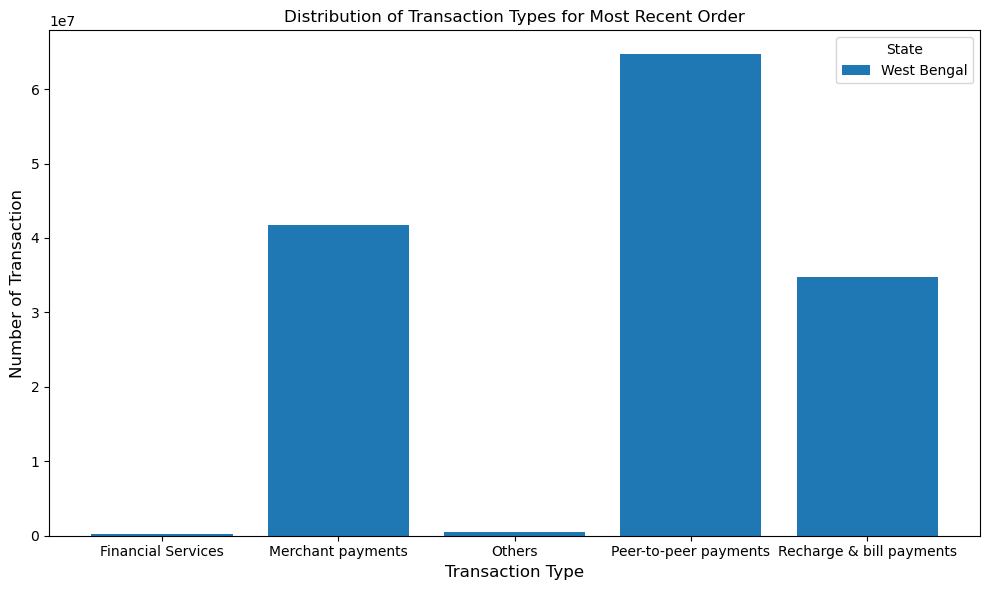

```python
import matplotlib.pyplot as plt
import pandas as pd

# Identify the most recent quarter

most_recent_year = State_tax_split['Year'].max()
most_recent_quarter = State_tax_split[State_tax_split['Year']== most_recent_year]['Quarter'].max()

# Filter data for the most recent quarter

recent_data = State_tax_split[(State_tax_split['Year'] == most_recent_year) & (State_tax_split['Quarter'] == most_recent_quarter)]

# Group by State and Transaction Type and Sum the Transaction

transaction_distribution = recent_data.groupby(['State', 'Transaction Type'])['Transactions'].sum().reset_index()


# for each state, plot the transaction distribution

for state in transaction_distribution['State'].unique():
    state_data = transaction_distribution[transaction_distribution['State']== state]
plt.figure(figsize=(10,6))
plt.bar(state_data['Transaction Type'], state_data['Transactions'],label=state)
plt.title('Distribution of Transaction Types for Most Recent Order')
plt.xlabel('Transaction Type', fontsize=12)
plt.ylabel('Number of Transaction', fontsize=12)
plt.legend(title='State')
plt.tight_layout()
plt.show()
```

## Question 2.8: Find unique mapping between district name and district code

1. Identify the unique mapping between district names and district codes from the dataset. [hint: you can use drop_duplicates()]

```python
unique_district_mapping = District_tax_users[['District', 'Code']].drop_duplicates()

print(unique_district_mapping.head())
```

```
                    District  Code
0                   Nicobars  AN01
1   North And Middle Andaman  AN02
2              South Andaman  AN03
42                 Anantapur  AP01
43                  Chittoor  AP02
```

2. Create a CSV file containing the unique district name and district code mappings.

```python
output_file = 'unique_district_mappings.csv'
unique_district_mapping.to_csv(output_file, index=False)
```

3. Export the CSV file.

```python
print(f"Unique district mappings have been exported to {output_file}")
```

```
Unique district mappings have been exported to unique_district_mappings.csv
```

## Task 3: Data Quality Checks

Question 3.1: Ensure data consistency across state and district levels

1. For each state, calculate the total number of transactions, total transaction amount, and total registered users by summing up the values from the district level data.

```python
district_compare =  District_tax_users.groupby('State').agg({
    'Transactions': 'sum',
    'Amount (INR)': 'sum',
    'Registered Users': 'sum'
}).reset_index()
```

```python
state_compare = State_tax__users.groupby('State').agg({
    'Transactions': 'sum',
    'Amount (INR)': 'sum',
    'Registered Users': 'sum'
}).reset_index()
```

```python
district_compare.head()
```

|  | State | Transactions | Amount (INR) | Registered Users |
| --- | --- | --- | --- | --- |
| 0 | Andaman & Nicobar Islands | 1223565 | 3.641818e+09 | 408396 |
| 1 | Andhra Pradesh | 1781091169 | 3.860292e+12 | 158007957 |
| 2 | Arunachal Pradesh | 8043799 | 2.225183e+10 | 1862214 |
| 3 | Assam | 123577981 | 2.814087e+11 | 26860751 |
| 4 | Bihar | 713643889 | 1.639579e+12 | 115284760 |

```python
state_compare.head()
```

|  | State | Transactions | Amount (INR) | Registered Users |
| --- | --- | --- | --- | --- |
| 0 | Andaman & Nicobar Islands | 1223565 | 3.641818e+09 | 408396 |
| 1 | Andhra Pradesh | 1781091169 | 3.187847e+12 | 158007957 |
| 2 | Arunachal Pradesh | 8043799 | 2.225183e+10 | 1862214 |
| 3 | Assam | 123577981 | 2.814087e+11 | 26860751 |
| 4 | Bihar | 713643889 | 1.639579e+12 | 115284760 |

2. Compare the results with the corresponding values at the state level to ensure they match

```python
# Merge district-level totals with state-level data
merged_data = pd.merge(state_compare, district_compare, on='State', how='outer')
```

```python
merged_data
```

|  | State | Transactions_x | Amount (INR)_x | Registered Users_x | Transactions_y | Amount (INR)_y | Registered Users_y |
| --- | --- | --- | --- | --- | --- | --- | --- |
| 0 | Andaman & Nicobar Islands | 1223565 | 3.641818e+09 | 408396 | 1223565 | 3.641818e+09 | 408396 |
| 1 | Andhra Pradesh | 1781091169 | 3.187847e+12 | 158007957 | 1781091169 | 3.860292e+12 | 158007957 |
| 2 | Arunachal Pradesh | 8043799 | 2.225183e+10 | 1862214 | 8043799 | 2.225183e+10 | 1862214 |
| 3 | Assam | 123577981 | 2.814087e+11 | 26860751 | 123577981 | 2.814087e+11 | 26860751 |
| 4 | Bihar | 713643889 | 1.639579e+12 | 115284760 | 713643889 | 1.639579e+12 | 115284760 |
| 5 | Chandigarh | 25516542 | 5.371208e+10 | 3801466 | 25516542 | 5.371208e+10 | 3801466 |
| 6 | Chhattisgarh | 241908549 | 4.156353e+11 | 37448388 | 241908549 | 4.156353e+11 | 37448388 |
| 7 | Dadra & Nagar Haveli and Daman & Diu | 12462185 | 1.865878e+10 | 2701112 | 12462185 | 1.865878e+10 | 2701112 |
| 8 | Delhi | 1011031124 | 1.649942e+12 | 95374654 | 1011031124 | 1.649942e+12 | 95374654 |
| 9 | Goa | 24481604 | 4.427187e+10 | 4755320 | 24481604 | 4.427187e+10 | 4755320 |
| 10 | Gujarat | 612992823 | 1.105329e+12 | 126380032 | 612992823 | 1.105329e+12 | 126380032 |
| 11 | Haryana | 567751410 | 1.059832e+12 | 85564119 | 567751410 | 1.059832e+12 | 85564119 |
| 12 | Himachal Pradesh | 52987445 | 9.786546e+10 | 13373980 | 52987445 | 9.786546e+10 | 13373980 |
| 13 | Jammu & Kashmir | 45053328 | 1.094954e+11 | 9756438 | 45053328 | 1.094954e+11 | 9756438 |
| 14 | Jharkhand | 275270987 | 4.905701e+11 | 44768682 | 275270987 | 4.905701e+11 | 44768682 |
| 15 | Karnataka | 2981044533 | 4.361396e+12 | 203098564 | 2981044533 | 4.361396e+12 | 203098564 |
| 16 | Kerala | 223637876 | 3.729599e+11 | 51267042 | 223637876 | 3.729599e+11 | 51267042 |
| 17 | Ladakh | 1880109 | 6.606978e+09 | 579825 | 1880109 | 6.606978e+09 | 579825 |
| 18 | Lakshadweep | 71610 | 1.921587e+08 | 34223 | 71610 | 1.921587e+08 | 34223 |
| 19 | Madhya Pradesh | 1100253728 | 1.915101e+12 | 125339823 | 1100253728 | 1.915101e+12 | 125339823 |
| 20 | Maharashtra | 2833670154 | 4.290995e+12 | 315783658 | 2833670154 | 4.290995e+12 | 315783658 |
| 21 | Manipur | 12318043 | 3.579325e+10 | 2317734 | 12318043 | 3.579325e+10 | 2317734 |
| 22 | Meghalaya | 5648913 | 1.254162e+10 | 1436472 | 5648913 | 1.254162e+10 | 1436472 |
| 23 | Mizoram | 2162776 | 6.317141e+09 | 605612 | 2162776 | 6.317141e+09 | 605612 |
| 24 | Nagaland | 5864977 | 1.638757e+10 | 1440387 | 5864977 | 1.638757e+10 | 1440387 |
| 25 | Odisha | 740479146 | 1.220615e+12 | 80404103 | 740479146 | 1.220615e+12 | 80404103 |
| 26 | Puducherry | 17292386 | 3.209769e+10 | 2785162 | 17292386 | 3.209769e+10 | 2785162 |
| 27 | Punjab | 181336904 | 3.941773e+11 | 45811761 | 181336904 | 3.941773e+11 | 45811761 |
| 28 | Rajasthan | 1382918930 | 2.625584e+12 | 149770064 | 1382918930 | 2.625584e+12 | 149770064 |
| 29 | Sikkim | 6483948 | 1.415554e+10 | 1279199 | 6483948 | 1.415554e+10 | 1279199 |
| 30 | Tamil Nadu | 800399873 | 1.481448e+12 | 132437426 | 800399873 | 1.481448e+12 | 132437426 |
| 31 | Telangana | 2347430243 | 4.574246e+12 | 149224214 | 2347430243 | 4.574246e+12 | 149224214 |
| 32 | Tripura | 12018152 | 2.097051e+10 | 3661575 | 12018152 | 2.097051e+10 | 3661575 |
| 33 | Uttar Pradesh | 1314714390 | 2.399757e+12 | 246200404 | 1314714390 | 2.399757e+12 | 246200404 |
| 34 | Uttarakhand | 124011162 | 2.150715e+11 | 23792747 | 124011162 | 2.150715e+11 | 23792747 |
| 35 | West Bengal | 942286041 | 1.452707e+12 | 144242183 | 942286041 | 1.452707e+12 | 144242183 |

3. Display any discrepancies found between the district-level and state-level data.

```python
# Identify inconsistencies
inconsistencies = merged_data[
    (merged_data['Transactions_x'] != merged_data['Transactions_y']) |
    (merged_data['Amount (INR)_x'] != merged_data['Amount (INR)_y']) |
    (merged_data['Registered Users_x'] != merged_data['Registered Users_y'])
]
if inconsistencies.empty:
    print("Data is consistent across state and district levels.")
else:
    print("Inconsistencies found:")
    print(inconsistencies)
```

```
Inconsistencies found:
                                   State  Transactions_x  Amount (INR)_x  \
0              Andaman & Nicobar Islands         1223565    3.641818e+09
1                         Andhra Pradesh      1781091169    3.187847e+12
2                      Arunachal Pradesh         8043799    2.225183e+10
3                                  Assam       123577981    2.814087e+11
4                                  Bihar       713643889    1.639579e+12
5                             Chandigarh        25516542    5.371208e+10
6                           Chhattisgarh       241908549    4.156353e+11
7   Dadra & Nagar Haveli and Daman & Diu        12462185    1.865878e+10
8                                  Delhi      1011031124    1.649942e+12
9                                    Goa        24481604    4.427187e+10
10                               Gujarat       612992823    1.105329e+12
11                               Haryana       567751410    1.059832e+12
12                      Himachal Pradesh        52987445    9.786546e+10
```

[output cut: 59 more lines]

## Task 4: Data Merging and Advanced Analysis

Question 4.1: Ratio of users to population by state

1. Merge the State_Txn and Users dataset with the District Demographics dataset to calculate the ratio of registered users to the population for each state. Display the results in a tabular format.

```python
# Merge datasets
merged_data = pd.merge(State_tax__users, District_demographics, on='State')

# Calculate the ratio of registered users to population
merged_data['User_Population_Ratio'] = merged_data['Registered Users'] / merged_data['Population']

# Display the results in tabular format
print(merged_data[['State', 'User_Population_Ratio']])
```

```
                           State  User_Population_Ratio
0      Andaman & Nicobar Islands               0.182943
1      Andaman & Nicobar Islands               0.063828
2      Andaman & Nicobar Islands               0.028302
3      Andaman & Nicobar Islands               0.255279
4      Andaman & Nicobar Islands               0.089065
...                          ...                    ...
10383                West Bengal               3.763936
10384                West Bengal               3.528340
10385                West Bengal               6.140777
10386                West Bengal               2.202899
10387                West Bengal               5.991631

[10388 rows x 2 columns]
```

2. Create a column chart depicting the ratio of users to population by state.

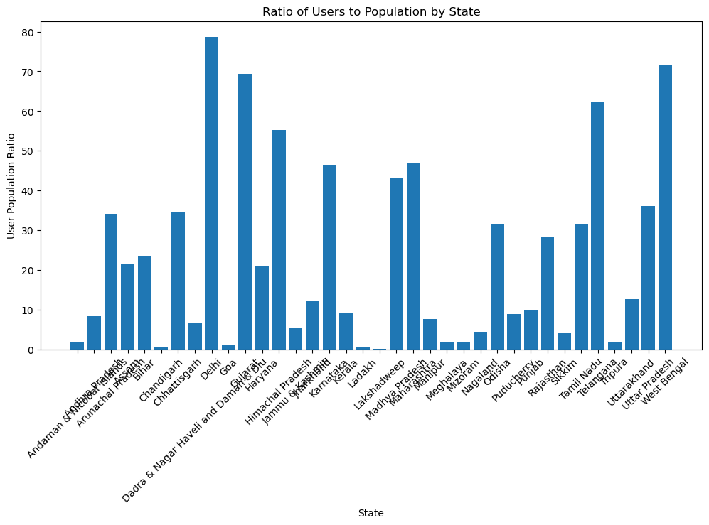

```python
import pandas as pd
import matplotlib.pyplot as plt
# Create a column chart
plt.figure(figsize=(12, 6))
plt.bar(merged_data['State'], merged_data['User_Population_Ratio'])
plt.xlabel('State')
plt.ylabel('User Population Ratio')
plt.title('Ratio of Users to Population by State')
plt.xticks(rotation=45)
plt.show()
```

## Question 4.2: Correlate population density with transaction volume

1. Merge the District_Txn and Users dataset with the District Demographics dataset.

```python
# Merge datasets based on a common identifier (e.g., 'District')
merged_data = pd.merge(District_tax_users ,District_demographics, on='District')
```

2. Calculate the correlation between population density and transaction volume.

```python
# Calculate population density
merged_data['Population Density'] = merged_data['Population'] / merged_data['Area (sq km)']
```

[figure not shown]

```
Correlation Coefficient: 0.3573243033148557
```

```python
import pandas as pd
import matplotlib.pyplot as plt
import seaborn as sns
# Calculate correlation coefficient
correlation = merged_data['Population'].corr(merged_data['Transactions'])
# Create a scatter plot

plt.figure(figsize=(10, 6))
sns.scatterplot(x='Population', y='Transactions', data=merged_data)
plt.title('Correlation between Population Density and Transactions')
plt.xlabel('Population')
plt.ylabel('Transactions')
plt.show()

print(f"Correlation Coefficient: {correlation}")
```

## Question 4.3: Average transaction amount per user

1. Merge relevant datasets to calculate the average transaction amount per user for each state. Display the results in a tabular format.

```python
# Step 1: Merge the State_Txn and Users dataset with the District Demographics dataset
state_data_merged = pd.merge(State_tax__users, District_demographics, on='State', how='inner')

# Step 2: Calculate the average transaction amount per user for each state
state_data_merged['Avg_Transaction_Per_User'] = state_data_merged['Amount (INR)'] / state_data_merged['Registered Users']

# Step 3: Display the results in a tabular format
avg_transaction_per_user = state_data_merged[['State', 'Avg_Transaction_Per_User']].groupby('State').agg({'Avg_Transaction_Per_User': 'mean'}).reset_index()
print(avg_transaction_per_user)
```

```
                                   State  Avg_Transaction_Per_User
0              Andaman & Nicobar Islands               6846.811194
1                         Andhra Pradesh              17502.277427
2                      Arunachal Pradesh               9868.093852
3                                  Assam               8499.768302
4                                  Bihar              11287.137833
5                             Chandigarh              12860.471685
6                           Chhattisgarh               9215.205433
7   Dadra & Nagar Haveli and Daman & Diu               6168.978161
8                                  Delhi              14791.885162
9                                    Goa               7746.679818
10                               Gujarat               7370.452702
11                               Haryana              10362.129741
12                      Himachal Pradesh               6373.195303
13                       Jammu & Kashmir              10217.258123
```

[output cut: 22 more lines]

2. Identify the top 5 states with the highest average transaction amount per user and the top 5 states with the lowest average transaction amount per user. Display the results.

```python
# Step 4: Identify the top 5 states with the highest average transaction amount per user
top_5_states_highest = avg_transaction_per_user.nlargest(5, 'Avg_Transaction_Per_User')
print("\nTop 5 States with Highest Average Transaction Amount per User:")
print(top_5_states_highest)

# Step 5: Identify the top 5 states with the lowest average transaction amount per user
top_5_states_lowest = avg_transaction_per_user.nsmallest(5, 'Avg_Transaction_Per_User')
print("\nTop 5 States with Lowest Average Transaction Amount per User:")
print(top_5_states_lowest)
```

```
Top 5 States with Highest Average Transaction Amount per User:
             State  Avg_Transaction_Per_User
31       Telangana              23774.041127
1   Andhra Pradesh              17502.277427
15       Karnataka              17318.863969
8            Delhi              14791.885162
28       Rajasthan              13708.117474

Top 5 States with Lowest Average Transaction Amount per User:
                                   State  Avg_Transaction_Per_User
32                               Tripura               4956.287167
18                           Lakshadweep               5492.605845
16                                Kerala               6038.016882
7   Dadra & Nagar Haveli and Daman & Diu               6168.978161
12                      Himachal Pradesh               6373.195303
```

## Question 4.4: Device brand usage ratio

1. Merge the State_DeviceData dataset with the State_Txn and Users dataset.

```python
# Merge datasets based on a common identifier (e.g., 'State')
merged_data = pd.merge(State_device_data,State_tax__users, on='State')
```

```python
State_device_data
```

|  | State | Year | Quarter | Brand | Registered Users | Percentage |
| --- | --- | --- | --- | --- | --- | --- |
| 0 | Andaman & Nicobar Islands | 2018 | 1 | Xiaomi | 1665 | 0.247033 |
| 1 | Andaman & Nicobar Islands | 2018 | 1 | Samsung | 1445 | 0.214392 |
| 2 | Andaman & Nicobar Islands | 2018 | 1 | Vivo | 982 | 0.145697 |
| 3 | Andaman & Nicobar Islands | 2018 | 1 | Oppo | 501 | 0.074332 |
| 4 | Andaman & Nicobar Islands | 2018 | 1 | OnePlus | 332 | 0.049258 |
| ... | ... | ... | ... | ... | ... | ... |
| 5539 | West Bengal | 2021 | 2 | Lenovo | 350841 | 0.019513 |
| 5540 | West Bengal | 2021 | 2 | Asus | 297579 | 0.016551 |
| 5541 | West Bengal | 2021 | 2 | Huawei | 272965 | 0.015182 |
| 5542 | West Bengal | 2021 | 2 | Apple | 201393 | 0.011201 |
| 5543 | West Bengal | 2021 | 2 | Others | 1928653 | 0.107267 |

5544 rows × 6 columns

```python
State_tax__users
```

|  | State | Year | Quarter | Transactions | Amount (INR) | ATV (INR) | Registered Users | App Opens |
| --- | --- | --- | --- | --- | --- | --- | --- | --- |
| 0 | Andaman & Nicobar Islands | 2018 | 1 | 6658 | 1.463176e+07 | 2197.621091 | 6740 | 0 |
| 1 | Andaman & Nicobar Islands | 2018 | 2 | 11340 | 2.833854e+07 | 2498.989022 | 9405 | 0 |
| 2 | Andaman & Nicobar Islands | 2018 | 3 | 16265 | 5.555747e+07 | 3415.768284 | 12149 | 0 |
| 3 | Andaman & Nicobar Islands | 2018 | 4 | 23758 | 9.054834e+07 | 3811.277720 | 15222 | 0 |
| 4 | Andaman & Nicobar Islands | 2019 | 1 | 30486 | 1.022997e+08 | 3355.630147 | 18596 | 0 |
| ... | ... | ... | ... | ... | ... | ... | ... | ... |
| 499 | West Bengal | 2020 | 2 | 57676797 | 1.000994e+11 | 1735.523418 | 13222022 | 198589332 |
| 500 | West Bengal | 2020 | 3 | 79954504 | 1.568134e+11 | 1961.282329 | 14448366 | 246554831 |
| 501 | West Bengal | 2020 | 4 | 100340645 | 1.991655e+11 | 1984.893473 | 15662093 | 291721919 |
| 502 | West Bengal | 2021 | 1 | 118254052 | 2.429372e+11 | 2054.366877 | 16808799 | 316832674 |
| 503 | West Bengal | 2021 | 2 | 141897437 | 2.794348e+11 | 1969.273138 | 17979979 | 275341466 |

504 rows × 8 columns

```python
2.	Calculate the ratio of users using each device brand to the total number of registered users in each state. Display the results in a tabular format.
```

```python
# Calculate the ratio of users using each device brand to the total number of registered users for each state
device_brand_usage_ratio = merged_data.groupby('State').apply(lambda State_device_data :State_device_data ['Brand'].value_counts() / State_tax__users['Registered Users'].sum())
```

```python
device_brand_usage_ratio
```

```
State                      Brand
Andaman & Nicobar Islands  Xiaomi      8.140007e-08
                           Samsung     8.140007e-08
                           Vivo        8.140007e-08
                           Oppo        8.140007e-08
                           OnePlus     8.140007e-08
                                           ...
West Bengal                Others      8.140007e-08
                           Micromax    7.558578e-08
                           Huawei      6.395719e-08
                           Gionee      1.744287e-08
                           Apple       5.814290e-09
Name: count, Length: 448, dtype: float64
```

3. Create a bar chart depicting the device brand usage ratio for each state.

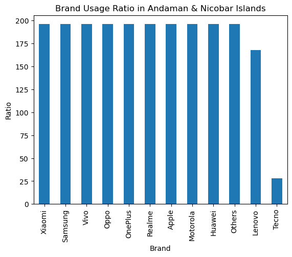

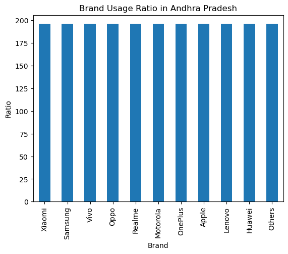

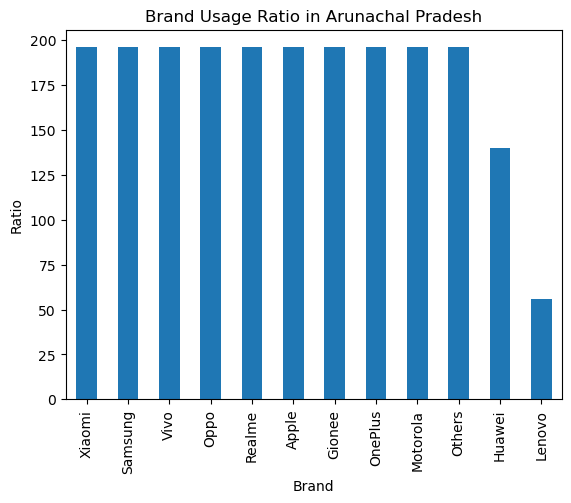

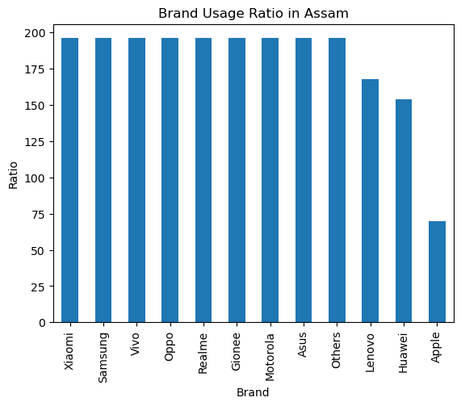

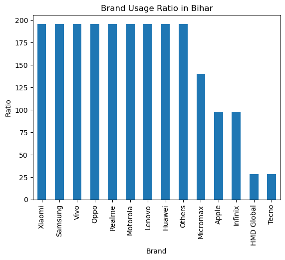

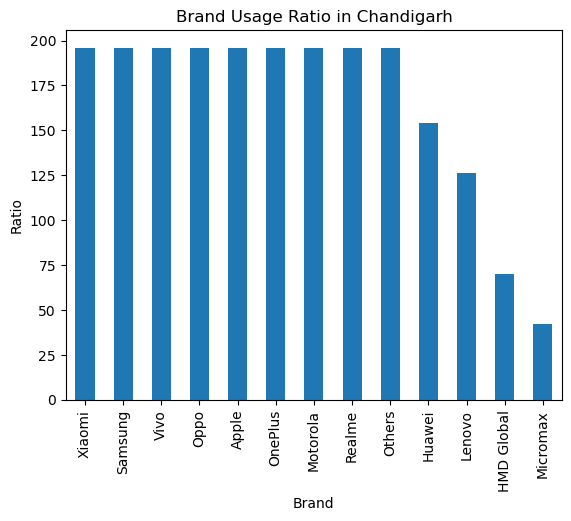

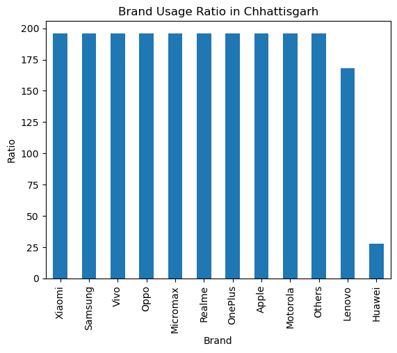

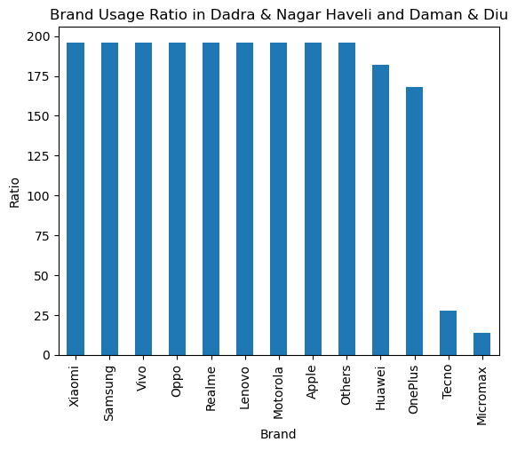

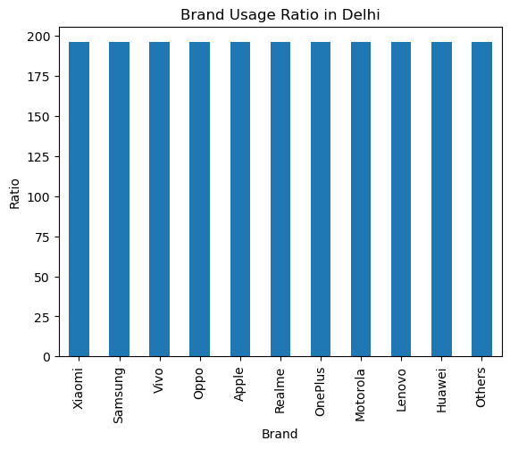

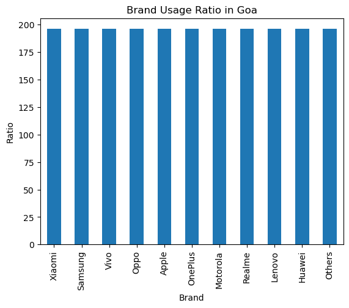

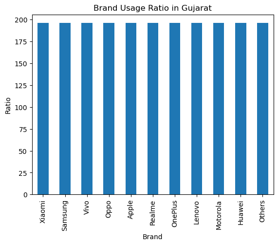

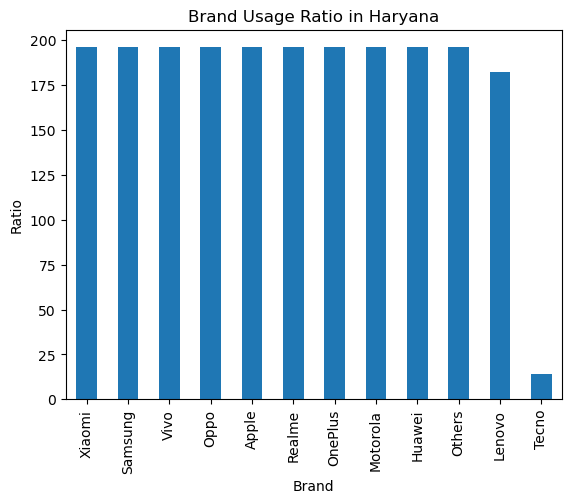

[24 more figures not shown]

```python
# Create a bar chart for each state
import pandas as pd
import matplotlib.pyplot as plt
for state in merged_data['State'].unique():
    state_data = merged_data[merged_data['State'] == state]
    state_data['Brand'].value_counts().plot(kind='bar')
    plt.title(f'Brand Usage Ratio in {state}')
    plt.xlabel('Brand')
    plt.ylabel('Ratio')
    plt.show()
```

## Task 5: Data Visualization

Question 5.1: Plot the total transactions and amount over time for a selected state

1. Create a line plot showing the total number of transactions and the total transaction amount over time (years and quarters) for a selected state.

[Hint: you can select any state, maybe your home state or state with max transactions]

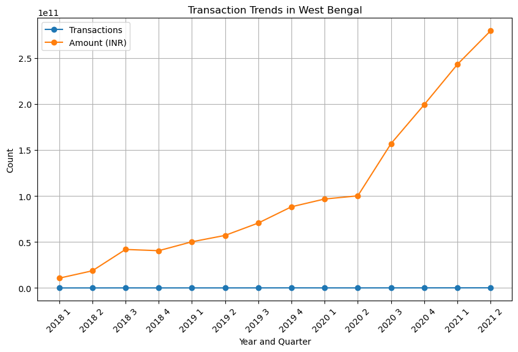

```python
import pandas as pd
import matplotlib.pyplot as plt

# Assuming you have a DataFrame named 'df' with columns 'State', 'Year', 'Quarter', 'Transactions', and 'Amount'

# Select a state for analysis (e.g., 'West Bengal')
state_data = State_tax__users[State_tax__users['State'] == 'West Bengal']

# Create a new column for combined year and quarter
state_data['Year_Quarter'] = state_data['Year'].astype(str) + ' ' + state_data['Quarter'].astype(str)

# Create a line plot
plt.figure(figsize=(10, 6))
plt.plot(state_data['Year_Quarter'], state_data['Transactions'], marker='o', linestyle='-', label='Transactions')
plt.plot(state_data['Year_Quarter'], state_data['Amount (INR)'], marker='o', linestyle='-', label='Amount (INR)')
plt.xlabel('Year and Quarter')
plt.ylabel('Count')
plt.title('Transaction Trends in West Bengal')
plt.xticks(rotation=45)
plt.grid(True)
plt.legend()
plt.show()
```

## Question 5.2: Create a pie chart showing the distribution of transaction types for a specific quarter

1. Create a pie chart showing the distribution of different transaction types for a selected state and quarter.

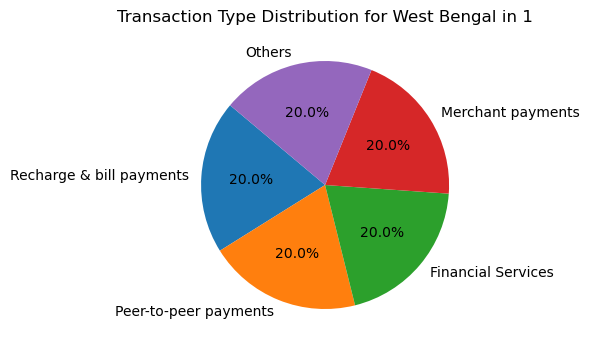

```python
import pandas as pd
import matplotlib.pyplot as plt

# Assuming you have a DataFrame named 'df' with columns 'State', 'Quarter', 'Transaction Type', and 'Count'

# Select a state and quarter for analysis (e.g., 'West Bengal', 'Q1 2023')
selected_state = 'West Bengal'
selected_quarter = 1

# Filter the data for the selected state and quarter
filtered_data = State_tax_split[(State_tax_split['State'] == selected_state) & (State_tax_split['Quarter'] == selected_quarter)]

# Group the filtered data by 'TransactionType' and count the occurrences
transaction_counts = filtered_data['Transaction Type'].value_counts()

# Create a pie chart
plt.figure(figsize=(4, 8))
plt.pie(transaction_counts, labels=transaction_counts.index, autopct='%1.1f%%', startangle=140)
plt.title(f'Transaction Type Distribution for {selected_state} in {selected_quarter}')
plt.show()
```

## Question 5.3: Visualize the population density of districts in a selected state

1. Create a bar plot showing the population density of districts in a selected state.

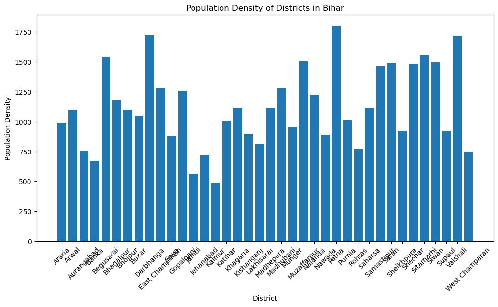

```python
import pandas as pd
import matplotlib.pyplot as plt

# Assuming you have a DataFrame named 'df' with columns 'State', 'District', 'Population', and 'Area'

# Select a state for analysis (e.g., 'West Bengal')
selected_state = ('Bihar')

# Filter the data for the selected state
state_data = District_demographics[District_demographics['State'] == selected_state]

# Calculate population density for each district
state_data['Population Density'] = state_data['Population'] / state_data['Area (sq km)']

# Create a bar plot
plt.figure(figsize=(12, 6))
plt.bar(state_data['District'], state_data['Population Density'])
plt.xlabel('District')
plt.ylabel('Population Density')
plt.title(f'Population Density of Districts in {selected_state}')
plt.xticks(rotation=45)
plt.show()
```